# R Notebook

#For performing the EDA, we will have to install and load the following packages:

```r
library(tidyverse)
library(ggplot2)
library(dplyr)
library(DataExplorer)
library(pROC)
library(glmnet)
library(aqp)
library(soilDB)
# To access correlation matrix plot
library("PerformanceAnalytics")
```

# Upload the dataset

```r
CustomerRetention
```

| Gender | SeniorCitizen | Partner | Dependents | Tenure | PhoneService | MultipleLines | InternetService | OnlineSecurity | OnlineBackup | DeviceProtection | TechSupport | StreamingTV | StreamingMovies | Contract | PaperlessBilling | PaymentMethod | MonthlyCharges | TotalCharges | Status | Status_new |
| --- | --- | --- | --- | --- | --- | --- | --- | --- | --- | --- | --- | --- | --- | --- | --- | --- | --- | --- | --- | --- |
| Female | 0 | Yes | No | 1 | No | No phone service | DSL | No | Yes | No | No | No | No | Month-to-month | Yes | Electronic check | 29.85 | 29.85 | Current | Current |
| Male | 0 | No | No | 34 | Yes | No | DSL | Yes | No | Yes | No | No | No | One year | No | Mailed check | 56.95 | 1889.50 | Current | Current |
| Male | 0 | No | No | 2 | Yes | No | DSL | Yes | Yes | No | No | No | No | Month-to-month | Yes | Mailed check | 53.85 | 108.15 | Left | Left |
| Male | 0 | No | No | 45 | No | No phone service | DSL | Yes | No | Yes | Yes | No | No | One year | No | Bank transfer (automatic) | 42.30 | 1840.75 | Current | Current |
| Female | 0 | No | No | 2 | Yes | No | Fiber optic | No | No | No | No | No | No | Month-to-month | Yes | Electronic check | 70.70 | 151.65 | Left | Left |
| Female | 0 | No | No | 8 | Yes | Yes | Fiber optic | No | No | Yes | No | Yes | Yes | Month-to-month | Yes | Electronic check | 99.65 | 820.50 | Left | Left |
| Male | 0 | No | Yes | 22 | Yes | Yes | Fiber optic | No | Yes | No | No | Yes | No | Month-to-month | Yes | Credit card (automatic) | 89.10 | 1949.40 | Current | Current |
| Female | 0 | No | No | 10 | No | No phone service | DSL | Yes | No | No | No | No | No | Month-to-month | No | Mailed check | 29.75 | 301.90 | Current | Current |
| Female | 0 | Yes | No | 28 | Yes | Yes | Fiber optic | No | No | Yes | Yes | Yes | Yes | Month-to-month | Yes | Electronic check | 104.80 | 3046.05 | Left | Left |
| Male | 0 | No | Yes | 62 | Yes | No | DSL | Yes | Yes | No | No | No | No | One year | No | Bank transfer (automatic) | 56.15 | 3487.95 | Current | Current |

[output cut: 990 more lines]

```r
NA
```

# Answer 1.1

# Data preparation and Exploratory Data Analysis

# data frame has 6999 records and 20 variables, characteristics provided by the dim function

# Exploratory Data Analysis or EDA is a statistical approach or technique for analyzing data sets in order to summarize their important and main characteristics generally by using some visual aids. The EDA approach can be used to gather knowledge about the following aspects of data:

# Main characteristics or features of the data.

# The variables and their relationships.

# Finding out the important variables that can be used in our problem.

# Below is the performance of the EDA under two broad classifications:

#(1) Descriptive Statistics, which includes mean, median, mode, inter-quartile range, and so on. #(2) Graphical Methods, which includes histogram, density estimation, box plots, and so on.

```r
dim(CustomerRetention)
```

```
[1] 6999   20
```

#Displays the type and a preview of all columns as a row so that it’s very easy to take in accoding to type of variables

```r
glimpse(CustomerRetention)
```

```
Rows: 6,999
Columns: 21
$ Gender           <fct> Female, Male, Male, Male, Female, Female, Male, Female, Female, Male, Male, Male, Male, Male, Male, Female, Female,~
$ SeniorCitizen    <int> 0, 0, 0, 0, 0, 0, 0, 0, 0, 0, 0, 0, 0, 0, 0, 0, 0, 0, 0, 0, 1, 0, 0, 0, 0, 0, 0, 0, 0, 0, 1, 1, 0, 0, 1, 0, 0, 0, 0~
$ Partner          <fct> Yes, No, No, No, No, No, No, No, Yes, No, Yes, No, Yes, No, No, Yes, No, No, Yes, No, No, Yes, No, Yes, Yes, No, Ye~
$ Dependents       <fct> No, No, No, No, No, No, Yes, No, No, Yes, Yes, No, No, No, No, Yes, No, Yes, Yes, No, No, No, No, No, Yes, No, Yes,~
$ Tenure           <int> 1, 34, 2, 45, 2, 8, 22, 10, 28, 62, 13, 16, 58, 49, 25, 69, 52, 71, 10, 21, 1, 12, 1, 58, 49, 30, 47, 1, 72, 17, 71~
$ PhoneService     <fct> No, Yes, Yes, No, Yes, Yes, Yes, No, Yes, Yes, Yes, Yes, Yes, Yes, Yes, Yes, Yes, Yes, Yes, Yes, No, Yes, Yes, Yes,~
$ MultipleLines    <fct> No phone service, No, No, No phone service, No, Yes, Yes, No phone service, Yes, No, No, No, Yes, Yes, No, Yes, No,~
$ InternetService  <fct> DSL, DSL, DSL, DSL, Fiber optic, Fiber optic, Fiber optic, DSL, Fiber optic, DSL, DSL, No, Fiber optic, Fiber optic~
$ OnlineSecurity   <fct> No, Yes, Yes, Yes, No, No, No, Yes, No, Yes, Yes, No internet service, No, No, Yes, Yes, No internet service, Yes, ~
$ OnlineBackup     <fct> Yes, No, Yes, No, No, No, Yes, No, No, Yes, No, No internet service, No, Yes, No, Yes, No internet service, No, No,~
$ DeviceProtection <fct> No, Yes, No, Yes, No, Yes, No, No, Yes, No, No, No internet service, Yes, Yes, Yes, Yes, No internet service, Yes, ~
$ TechSupport      <fct> No, No, No, Yes, No, No, No, No, Yes, No, No, No internet service, No, No, Yes, Yes, No internet service, No, Yes, ~
$ StreamingTV      <fct> No, No, No, No, No, Yes, Yes, No, Yes, No, No, No internet service, Yes, Yes, Yes, Yes, No internet service, Yes, N~
$ StreamingMovies  <fct> No, No, No, No, No, Yes, No, No, Yes, No, No, No internet service, Yes, Yes, Yes, Yes, No internet service, Yes, No~
$ Contract         <fct> Month-to-month, One year, Month-to-month, One year, Month-to-month, Month-to-month, Month-to-month, Month-to-month,~
$ PaperlessBilling <fct> Yes, No, Yes, No, Yes, Yes, Yes, No, Yes, No, Yes, No, No, Yes, Yes, No, No, No, No, Yes, Yes, No, No, Yes, No, Yes~
$ PaymentMethod    <fct> Electronic check, Mailed check, Mailed check, Bank transfer (automatic), Electronic check, Electronic check, Credit~
$ MonthlyCharges   <dbl> 29.85, 56.95, 53.85, 42.30, 70.70, 99.65, 89.10, 29.75, 104.80, 56.15, 49.95, 18.95, 100.35, 103.70, 105.50, 113.25~
$ TotalCharges     <dbl> 29.85, 1889.50, 108.15, 1840.75, 151.65, 820.50, 1949.40, 301.90, 3046.05, 3487.95, 587.45, 326.80, 5681.10, 5036.3~
$ Status           <chr> "Current", "Current", "Left", "Current", "Left", "Left", "Current", "Current", "Left", "Current", "Current", "Curre~
$ Status_new       <fct> Current, Current, Left, Current, Left, Left, Current, Current, Left, Current, Current, Current, Current, Left, Curr~
```

```r
#BasicSummary(CustomerRetention)
typeof(CustomerRetention)
```

```
[1] "list"
```

#Data Inspection for EDA in R to know mean median min, max for all the variables that is comes in description data exploration

```r
summary(CustomerRetention)
```

```
    Gender     SeniorCitizen    Partner    Dependents     Tenure      PhoneService          MultipleLines     InternetService
 Female:3467   Min.   :0.0000   No :3613   No :4894   Min.   : 0.00   No : 676     No              :3371   DSL        :2405
 Male  :3532   1st Qu.:0.0000   Yes:3386   Yes:2105   1st Qu.: 9.00   Yes:6323     No phone service: 676   Fiber optic:3075
               Median :0.0000                         Median :29.00                Yes             :2952   No         :1519
               Mean   :0.1619                         Mean   :32.38
               3rd Qu.:0.0000                         3rd Qu.:55.00
               Max.   :1.0000                         Max.   :72.00

             OnlineSecurity              OnlineBackup             DeviceProtection              TechSupport                StreamingTV
 No                 :3471   No                 :3070   No                 :3074    No                 :3448   No                 :2792
 No internet service:1519   No internet service:1519   No internet service:1519    No internet service:1519   No internet service:1519
 Yes                :2009   Yes                :2410   Yes                :2406    Yes                :2032   Yes                :2688




            StreamingMovies           Contract    PaperlessBilling                   PaymentMethod  MonthlyCharges    TotalCharges
 No                 :2762   Month-to-month:3847   No :2862         Bank transfer (automatic):1534   Min.   : 18.25   Min.   :  18.8
 No internet service:1519   One year      :1465   Yes:4137         Credit card (automatic)  :1512   1st Qu.: 35.48   1st Qu.: 401.9
 Yes                :2718   Two year      :1687                    Electronic check         :2350   Median : 70.35   Median :1397.5
                                                                   Mailed check             :1603   Mean   : 64.75   Mean   :2283.1
                                                                                                    3rd Qu.: 89.85   3rd Qu.:3796.9
                                                                                                    Max.   :118.75   Max.   :8684.8
                                                                                                                     NA's   :11
    Status            Status_new
 Length:6999        Current:5143
 Class :character   Left   :1856
 Mode  :character
```

#Note that there is significant correlation of TotalCharges with Tenure and MonthlyCharges. If collinearity is an #issue for the method I am using then I will not use MonthlyCharges

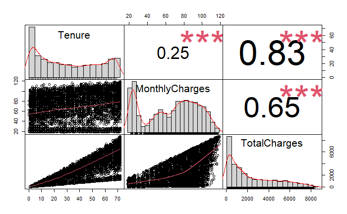

```r
# I will create a subset with the numeric variables I want to explore correlations for
CustomerRetention.numeric <- CustomerRetention %>%
  select(Tenure,MonthlyCharges,TotalCharges)
chart.Correlation(CustomerRetention.numeric , histogram=TRUE, pch=19)
```